# Avaliação Final

Lana Karolina da S. Reis

### Introdução

##### Vamos analisar os dados referentes ao Exame Nacional de Desempenho dos Estudantes (**ENADE**) do ano de 2017, mais precisamente o desempenho dos alunos do curso de Geografia Licenciatura no respectivo ano.

##### Serão avaliados as notas, bem como as características desses alunos (**Sexo**,**Turno** e **Região**), tudo isso com base nas análises descritivas feitas neste trabalho.

###### Obs.: para fins de praticidade, os dados importados já serão com os devidos tratamentos: 1) Variáveis selecionadas como pedido na prova; 2) Filtro do Curso Selecionado; 3) Transformação dos rótulos das variáveis categóricas; 4) NA’s retirados.

```
## # A tibble: 6 x 27
##   CO_GRUPO CO_REGIAO_CURSO NU_IDADE TP_SEXO CO_TURNO_GRADUA~ NT_GER QE_I01
##      <dbl>           <dbl>    <dbl> <chr>              <dbl>  <dbl> <chr>
## 1     3002               5       32 M                      4   39.3 B
## 2     3002               5       28 F                      4   42.1 A
## 3     3002               5       37 M                      4   43.5 B
## 4     3002               5       26 M                      4   27.7 A
## 5     3002               5       26 F                      4   53.8 B
## 6     3002               5       23 M                      4   75.2 A
## # ... with 20 more variables: QE_I02 <chr>, QE_I04 <chr>, QE_I05 <chr>,
## #   QE_I08 <chr>, QE_I21 <chr>, QE_I22 <chr>, QE_I23 <chr>, NT_OBJ_FG <dbl>,
## #   NT_OBJ_CE <dbl>, Sexo <chr>, Regiao <chr>, Turno <chr>, Estado_Civil <chr>,
## #   Cor_Raca <chr>, Escolaridade_Pai <chr>, Escolaridade_Mae <chr>,
## #   Renda_Familiar <chr>, Familiar_Graduado <chr>, Qdade_Livros <chr>,
## #   Horas_Estudo <chr>
```

##### Faremos então uma apresentação das variáveis presentes nos dados, com suas respectivas classificações quanto ao tipo de variável, bem como as medidas descritivas de todas elas.

```r
describe(bd$NT_OBJ_FG) # nota bruta da formação geral (quantitativo continuo)
```

```
## bd$NT_OBJ_FG
##        n  missing distinct     Info     Mean      Gmd
##     8808        0        9    0.965    48.16    22.07
##
## lowest :   0.0  12.5  25.0  37.5  50.0, highest:  50.0  62.5  75.0  87.5 100.0
##
## Value        0.0  12.5  25.0  37.5  50.0  62.5  75.0  87.5 100.0
## Frequency    162   476  1104  1823  2131  1814   956   285    57
## Proportion 0.018 0.054 0.125 0.207 0.242 0.206 0.109 0.032 0.006
```

```r
describe(bd$CO_GRUPO) # codigo do curso (quantitativo discreto)
```

```
## bd$CO_GRUPO
##        n  missing distinct     Info     Mean      Gmd
##     8808        0        1        0     3002        0
##
## Value      3002
## Frequency  8808
## Proportion    1
```

```r
describe(bd$CO_REGIAO_CURSO) # codigo da regiao do curso (quantitativo discreto)
```

```
## bd$CO_REGIAO_CURSO
##        n  missing distinct     Info     Mean      Gmd
##     8808        0        5    0.933    2.832    1.242
##
## lowest : 1 2 3 4 5, highest: 1 2 3 4 5
##
## Value          1     2     3     4     5
## Frequency    979  2698  2745  1600   786
## Proportion 0.111 0.306 0.312 0.182 0.089
```

```r
describe(bd$QE_I02) # etnia do estudante (qualitativo nominal)
```

```
## bd$QE_I02
##        n  missing distinct
##     8808        0        6
##
## lowest : A B C D E, highest: B C D E F
##
## Value          A     B     C     D     E     F
## Frequency   3428  1245   184  3632    68   251
## Proportion 0.389 0.141 0.021 0.412 0.008 0.028
```

```r
describe(bd$CO_TURNO_GRADUACAO) # codigo do turno do curso (quantitativo discreto)
```

```
## bd$CO_TURNO_GRADUACAO
##        n  missing distinct     Info     Mean      Gmd
##     8808        0        4    0.772    3.083    1.242
##
## Value          1     2     3     4
## Frequency   1981   582   968  5277
## Proportion 0.225 0.066 0.110 0.599
```

### Análise Estatística dos Dados

##### Faremos agora uma análise geral nos dados, identificando se existe alguma variável com valores nulos (**NA’s**).

```
##   CO_GRUPO CO_REGIAO_CURSO NU_IDADE TP_SEXO CO_TURNO_GRADUACAO NT_GER QE_I01
## 1        0               0        0       0                  0      0      0
##   QE_I02 QE_I04 QE_I05 QE_I08 QE_I21 QE_I22 QE_I23 NT_OBJ_FG NT_OBJ_CE Sexo
## 1      0      0      0      0      0      0      0         0         0    0
##   Regiao Turno Estado_Civil Cor_Raca Escolaridade_Pai Escolaridade_Mae
## 1      0     0            0        0                0                0
##   Renda_Familiar Familiar_Graduado Qdade_Livros Horas_Estudo
## 1              0                 0            0            0
```

##### Podemos perceber que não há valores nulos em nenhuma variável presente nos dados.

##### Analisaremos agora as notas gerais (*NT_GER*) dos alunos de Geografia Licenciatura, por meio das medidas descritivas.

| Quantidade | Media | Mediana | Moda | CV | Assimetria | Curtose | Minimo | Maximo |
| --- | --- | --- | --- | --- | --- | --- | --- | --- |
| 8808 | 45.36131 | 45.1 | 0 | 33.16799 | -0.02408845 | -0.3360316 | 0 | 95.4 |

##### Podemos perceber que a média das notas dos alunos está um pouco abaixo da nota média da prova (**Média = 45,4**), pois a nota pode variar de 0 a 98,10; 50% dos alunos tiraram notas um pouco inferiores em relação a média (**Mediana = 45,1**); e nenhum aluno tirou a nota máxima do exame (**Máximo = 95,4**). Em relação a disposição dos dados, percebemos pelo coeficiente de assimetria e curtose que se trata de uma amostra com assimetria negativa e de distribuição platicúrtica (**-0,02 e -0,34, respectivamente**)

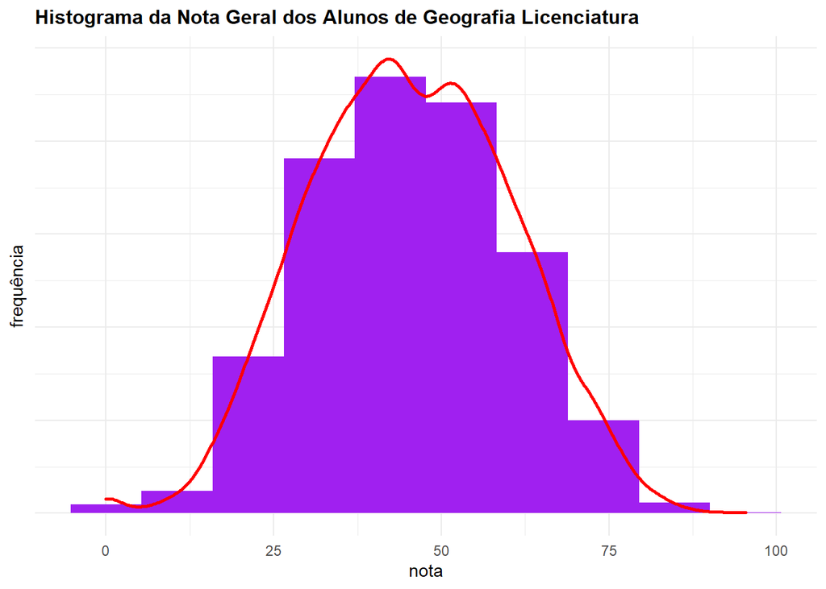

##### Através do histograma acima podemos constatar a disposição dos dados quanto a sua assimetria, que é levemente a esquerda.

##### Iremos analisar agora como essas notas se comportam quanto ao turno em que eles estão matriculados.

| Turno | Quantidade | Media | Mediana | Moda | CV | Assimetria | Curtose |
| --- | --- | --- | --- | --- | --- | --- | --- |
| Noturno | 5277 | 45.32109 | 45.10 | 58.4 | 32.61035 | -0.02489077 | -0.3505710 |
| Matutino | 1981 | 45.04609 | 44.90 | 0.0 | 35.08271 | -0.08018973 | -0.4108592 |
| Integral | 968 | 46.41973 | 46.45 | 35.9 | 33.43169 | 0.05537868 | -0.2574012 |
| Vespertino | 582 | 45.03849 | 43.40 | 39.3 | 30.88562 | 0.06577753 | -0.3450730 |
| Vespertino | 582 | 45.03849 | 43.40 | 42.2 | 30.88562 | 0.06577753 | -0.3450730 |
| Vespertino | 582 | 45.03849 | 43.40 | 53.2 | 30.88562 | 0.06577753 | -0.3450730 |

##### Percebemos que o turno com maior quantidade de alunos é o Noturno. O turno da Tarde aparece 3 vezes pois o turno apresenta 3 notas mais frequentemente (**Moda**).

##### De acordo com os dados podemos ver que existe indícios de que as notas não se diferenciam significativamente entre os cursos.

##### Para confirmar se essa diferença de fato não existe, vamos fazer um Teste de Hipóteses Não Paramétrico (usado quando não sabemos qual é a distribuição dos dados), pois sabemos que não se trata de uma Distribuição Normal (**Moda $\neq$ Media $\neq$ Moda**).

```
##
##  Shapiro-Wilk normality test
##
## data:  sample(teste1$NT_GER, 5000)
## W = 0.99732, p-value = 1.011e-07
```

```
##
##  Kruskal-Wallis rank sum test
##
## data:  teste1$NT_GER by teste1$Turno
## Kruskal-Wallis chi-squared = 4.413, df = 3, p-value = 0.2202
```

##### O teste de normalidade de Shapiro-Wilk rejeitou a hipótese de que a distribuição dos dados seja Normal (**Valor-P < 0,01%**). Então foi feito o teste não paramétrico Kruskal-Wallis de semelhança de grupos, em que não rejeitou-se a hipótese de que os turnos sejam semelhantes quanto a nota geral dos alunos (**Valor-P = 22,02%**). Esses testes levaram em consideração um nível de significância ($\alpha$) de 5%.

##### Faremos a seguir uma análise cruzada do Sexo e Turno.

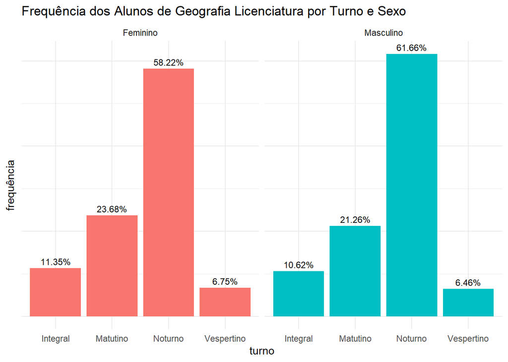

##### O gráfico acima mostra a frequência relativa dos alunos quanto ao sexo e a turma. Notamos haver indícios de associação entre os grupos, pois os turno se comportam de forma semelhante em ambos os sexos, mas para comprovar a análise empírica faremos o teste não paramétrico Qui-quadrado de Pearson, indicado para casos em que as variáveis envolvidas sejam categóricas e estejam dispostas em uma tabela de contingência.

```
##
##  Pearson's Chi-squared test
##
## data:  t4
## X-squared = 11.414, df = 3, p-value = 0.009684
```

##### O resultado do teste comprova o que observamos anteriormente, pois mostra que a 5% de significância os turnos têm associação com o sexo dos alunos (**Valor-P = 0,9%**).

##### A seguir uma análise do sexo dos alunos em relação a nota que eles obtiveram no exame.

```
## # A tibble: 2 x 8
##   Sexo      Quantidade Media Mediana  Moda    CV Assimetria Curtose
##   <chr>          <int> <dbl>   <dbl> <dbl> <dbl>      <dbl>   <dbl>
## 1 Feminino        4476  43.5    43.1  43.1  33.0     0.0625  -0.293
## 2 Masculino       4332  47.2    47.7  52.1  32.8    -0.147   -0.319
```

##### Podemos perceber que a melhor nota foi obtida pelo sexo masculino (**Média = 47,2**) e que 50% dos homens tiveram notas acima da média (**Mediana = 47,7**). A nota mais frequentemente vista foi 52,1 (**Moda**).

##### A distribuição da população feminina do curso possui assimetria positiva, diferentemente do visto nas notas gerais, indicando que mais mulheres tiveram notas menores que 50.

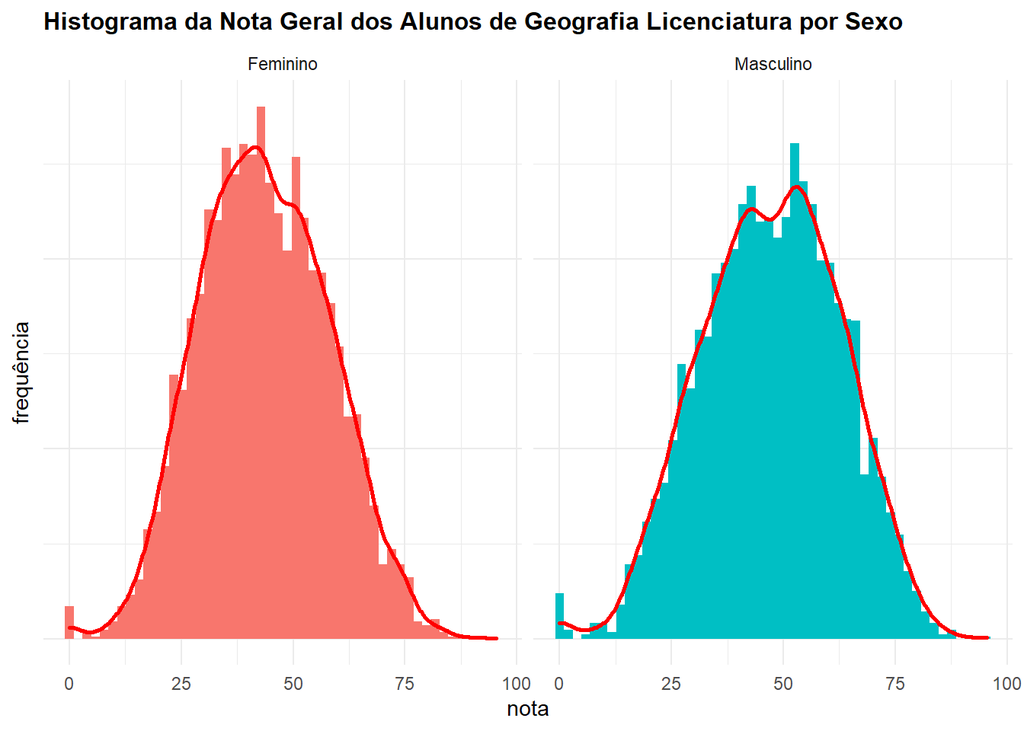

##### Com o gráfico percebemos que a curva do lado feminino tem a calda levemente mais pesada para o lado direito, com concentração dos dados no lado esquerdo, mostrando o que o coeficiente de assimetria indicou (assimetria positiva ou a direita). Já a curva do lado masculino é completamente o oposto.

##### Veremos a seguir se existe diferença no desempenho dos alunos quanto ao sexo.

```
##
##  Kruskal-Wallis rank sum test
##
## data:  teste1$NT_GER by teste1$Sexo
## Kruskal-Wallis chi-squared = 139.06, df = 1, p-value < 2.2e-16
```

##### Podemos afirmar que a 5% de significância o sexo masculino tenha desempenho diferente do sexo feminino (**Valor-P < 0,01%**)

##### Vamos analisar agora o cruzamento entre **Turno** e **Região**.

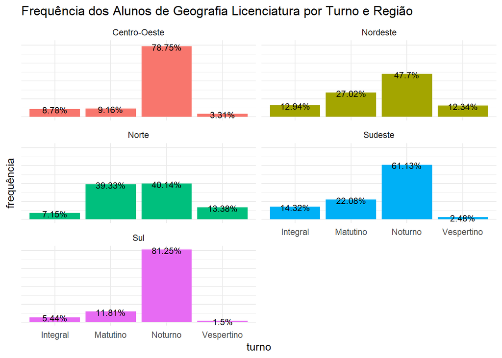

##### Vemos que há índicios de que a região Norte aparentemente não está associada ao turno, pois nos turnos Matutino e Noturno a frequência dos alunos é bem parecida. Entretanto para tirarmos alguma conclusão vamos fazer o teste Qui-quadrado novamente, por se tratar de variáveis categóricas.

```
##
##  Pearson's Chi-squared test
##
## data:  t5
## X-squared = 1039, df = 12, p-value < 2.2e-16
```

##### Concluímos que, a 5% de significância as regiões estão associadas aos turnos em que os alunos estão matriculados. Isso nos leva a crer que a região Norte e os turnos Manhã e Noite, nesta região, não tenha impactado significantemente o resultado do teste.

##### A seguir uma análise das regiões dos alunos em relação a nota que eles obtiveram no exame.

```
## # A tibble: 7 x 8
## # Groups:   Regiao [5]
##   Regiao       Quantidade Media Mediana  Moda    CV Assimetria Curtose
##   <chr>             <int> <dbl>   <dbl> <dbl> <dbl>      <dbl>   <dbl>
## 1 Sudeste            2745  48.4    49.7   0    33.1   -0.246    -0.251
## 2 Nordeste           2698  43.6    43.3  41.7  32.6   -0.0201   -0.191
## 3 Nordeste           2698  43.6    43.3  44.7  32.6   -0.0201   -0.191
## 4 Sul                1600  45.4    44.9  44.4  32.0    0.0819   -0.454
## 5 Norte               979  42.7    42.8  43.1  32.9    0.00548  -0.429
## 6 Norte               979  42.7    42.8  52.1  32.9    0.00548  -0.429
## 7 Centro-Oeste        786  43.9    42.8  59.2  33.5    0.151    -0.581
```

##### Vemos que a região mais populosa é a região Sudeste, em que a mesma contém as melhores notas. Já a região de pior desempenho foi a região Norte (**Média = 42,7**). Vemos regiões com assimetria negativa (Sudeste e Nordeste), por possuírem as notas mais altas, e as demais possuem assimetria positiva, por possuírem as notas mais baixas. Todas as regiões são platicúrticas.

[figure not shown]

##### Vemos com mais precisão que a região Sudeste é de fato a região que mais possui notas altas.

##### Veremos a seguir se existe diferença no desempenho dos alunos quanto a região.

```
##
##  Kruskal-Wallis rank sum test
##
## data:  teste1$NT_GER by teste1$Regiao
## Kruskal-Wallis chi-squared = 191.77, df = 4, p-value < 2.2e-16
```

##### Podemos afirmar que a 5% de significância as regiões têm desempenhos diferentes umas das outras.

### Conclusão

##### - A nota geral dos alunos depende tanto do sexo do aluno como da região que ele habita.